# Load Data

```python
import pandas as pd

# Load data
product_inventory_df = pd.read_csv('https://storage.googleapis.com/datalynn-datasets/interview-challenge/logistics-and-supply-chain/Accenture_4/product_inventory.csv')
sales_records_df = pd.read_csv('https://storage.googleapis.com/datalynn-datasets/interview-challenge/logistics-and-supply-chain/Accenture_4/sales_records.csv')
```

## Question 1: Basic SQL Knowledge

Write an SQL query to find the 'Product_Category' that had the most sales ('Quantity_Sold') in each 'Sales_Region'. Also include the total sales price for that category in each region.

### Solution

**Hints and Explanations**

The given SQL query is designed to find the product category that had the most sales (highest quantity sold) in each sales region, along with the total sales price for that category in each region. Let's break down the steps involved in solving this problem.

1. The query uses two common table expressions (CTEs) to perform the required calculations.
2. The first CTE, "sales_totals," aggregates the sales records by sales region and product category. It calculates the total quantity sold and the total sales price for each combination.
3. The second CTE, "ranked_sales," builds on the results of the "sales_totals" CTE. It uses the RANK() function to assign a rank to each product category within each sales region based on the total quantity sold. The highest-selling category within each region will have a rank of 1.
4. The final SELECT statement retrieves the desired information from the "ranked_sales" CTE. It selects the sales region, product category, total quantity sold, and total sales price. The WHERE clause filters the results to only include rows where the rank is 1, indicating the category with the highest sales in each region.
5. The query is executed using the pd.read_sql_query() function from the pandas library, which reads the SQL query result into a pandas DataFrame for further analysis.

Overall, the query joins the "sales_records_df" and "product_inventory_df" tables on the common "Product_ID" column, groups the data by sales region and product category, calculates the total quantity sold and sales price for each category in each region, ranks the categories within each region based on quantity sold, and finally selects the category with the highest sales in each region. The result is a DataFrame called "Most_Sale_df" containing the desired information.

```python
import json

product_inventory_df['Seasonality'] = product_inventory_df['Seasonality'].apply(json.dumps)

# The rest of your code...

import sqlite3
# read your data into pandas DataFrames
# connect to your sqlite database
conn = sqlite3.connect('database_name.db')

# Convert your Pandas dataframes to SQL tables
product_inventory_df.to_sql('product_inventory_df', conn, if_exists='replace', index=False)
sales_records_df.to_sql('sales_records_df', conn, if_exists='replace', index=False)

query3 = '''
  WITH sales_totals AS (
      SELECT
          sr.Sales_Region,
          pi.Product_Category,
          SUM(sr.Quantity_Sold) as Total_Quantity_Sold,
          SUM(sr.Quantity_Sold * sr.Sales_Price) as Total_Sales_Price
      FROM
          sales_records_df sr
      JOIN
          product_inventory_df pi
      ON
          sr.Product_ID = pi.Product_ID
      GROUP BY
          sr.Sales_Region,
          pi.Product_Category
  ),

  ranked_sales AS (
      SELECT
          Sales_Region,
          Product_Category,
          Total_Quantity_Sold,
          Total_Sales_Price,
          RANK() OVER (PARTITION BY Sales_Region ORDER BY Total_Quantity_Sold DESC) as rank
      FROM
          sales_totals
  )

  SELECT
      Sales_Region,
      Product_Category,
      Total_Quantity_Sold,
      Total_Sales_Price
  FROM
      ranked_sales
  WHERE
      rank = 1;
'''

Most_Sale_df = pd.read_sql_query(query3, conn)
# close the connection
conn.close()
Most_Sale_df
```

|  | Sales_Region | Product_Category | Total_Quantity_Sold | Total_Sales_Price |
| --- | --- | --- | --- | --- |
| 0 | East | Furniture | 1672374 | 5.906430e+09 |
| 1 | North | Furniture | 1663723 | 5.931265e+09 |
| 2 | South | Furniture | 1630840 | 5.767543e+09 |
| 3 | West | Furniture | 1622913 | 5.887891e+09 |

## Quesiton 2: Cost-Based Risk Metric - Validation

Assume that a stockout event's cost is proportional to the Product_Cost but inversely proportional to the Lead_Time (more lead time means a lesser impact as we have more time to react). At the same time, the cost of holding excess inventory is a function of Product_Cost and Current_Stock_Level. Given these conditions, define a cost-based risk metric that balances both stockouts and overstock situations. How would you validate this metric using historical data?

### Solution

**Hints and Explanations**

1. **Database Connection**:
   - Connect to the SQLite database.
   - Convert given Pandas dataframes (`product_inventory_df` and `sales_records_df`) into SQL tables within the database.
   - Fetch the relevant tables from the database and store them as Pandas dataframes.
   - Close the database connection to free up resources.
2. **Data Preparation**:
   - Merge the fetched dataframes (`product_inventory_df` and `sales_records_df`) based on the common 'Product_ID' column. This results in a unified dataframe containing both inventory and sales records for each product.
3. **Cost Calculations**:
   - Calculate the stockout cost: It's derived by taking the ratio of `Product_Cost` to `Lead_Time`. This represents the cost you'll incur if you stock out of a product, taking into account the lead time.
   - Calculate the overstock cost: Multiply a set proportion (0.1 in this code) with the `Product_Cost` and the `Current_Stock_Level`. This is the cost associated with holding more stock than necessary.
4. **Risk Metric Definition**:
   - Define weights for stockout and overstock situations. In this solution, stockout has been given more weight (0.6) compared to overstock (0.4).
   - Calculate the risk metric by combining both stockout and overstock costs using the assigned weights. This metric quantifies the overall cost-based risk for each product considering both stockout and overstock situations.

```python
import sqlite3
import pandas as pd

# connect to your sqlite database
conn = sqlite3.connect('database_name.db')

# Convert your Pandas dataframes to SQL tables
product_inventory_df.to_sql('product_inventory_df', conn, if_exists='replace', index=False)
sales_records_df.to_sql('sales_records_df', conn, if_exists='replace', index=False)

# read your data into pandas DataFrames
query1 = 'SELECT * FROM product_inventory_df'
query2 = 'SELECT * FROM sales_records_df'
product_inventory_df = pd.read_sql_query(query1, conn)
sales_records_df = pd.read_sql_query(query2, conn)

# close the connection
conn.close()

# merge the two dataframes on 'Product_ID'
df = pd.merge(product_inventory_df, sales_records_df, on='Product_ID')

# calculate stockout cost
df['stockout_cost'] = df['Product_Cost'] / df['Lead_Time']

# calculate overstock cost
overstock_cost_proportion = 0.1  # parameter that you may need to adjust
df['overstock_cost'] = overstock_cost_proportion * df['Product_Cost'] * df['Current_Stock_Level']

# define your risk metric
weight_stockout = 0.6
weight_overstock = 0.4
df['risk_metric'] = weight_stockout * df['stockout_cost'] + weight_overstock * df['overstock_cost']
```

## Question 3: Time to Stockout Forecasting - Time Series Analysis

Given the historical sales data and current stock levels, design a method to forecast the time to stockout for each product using a time series analysis approach. How would you account for both macro trends and seasonality in sales in your model? Furthermore, given the uncertainty in future sales, how would you calculate a confidence interval for your time to stockout forecast?

#### **Answer 3.3**

**Hints and Explanations**

1. Choose a specific product for which you want to forecast the time to stockout. In the given code, the product ID is obtained from the 'sales_records_df' DataFrame.
2. Retrieve the historical sales data for the selected product from the 'sales_records_df' DataFrame. Filter the DataFrame to only include records for the chosen product. Ensure that the sales data is sorted chronologically by the date of sale.
3. Convert the 'Date_of_Sale' column to a datetime format to enable time series analysis.
4. Set the 'Date_of_Sale' column as the index of the DataFrame to perform time-based operations.
5. Resample the sales data to the desired frequency (e.g., daily) to obtain the total sales quantity for each time period.
6. Decompose the time series into its constituent components, including trend, seasonality, and residuals. This step helps visualize the patterns and identify any underlying trends and seasonality in the sales data.
7. Fit a SARIMA (Seasonal Autoregressive Integrated Moving Average) model to the resampled sales data. SARIMA models are suitable for analyzing time series data that exhibit both trend and seasonality. In the given code, an SARIMA model with an order of (1, 1, 1) and a seasonal order of (1, 1, 1, 12) is used.
8. Use the fitted SARIMA model to predict sales for the next desired time period. In the given code, sales forecasts are generated for the next 30 days.
9. Retrieve the current stock level for the selected product from the 'product_inventory_df' DataFrame.
10. Estimate the time to stockout by dividing the current stock level by the forecasted sales quantity for the first time period. This assumes that sales will continue at the forecasted rate.

By applying these steps, you can leverage time series analysis techniques, such as SARIMA modeling, to forecast the time to stockout for a given product. It incorporates historical sales data, captures trends and seasonality, and provides an estimate of the remaining time until the product stock runs out.

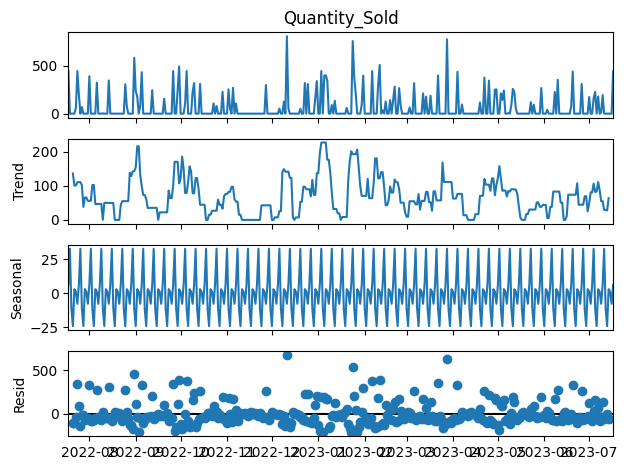

```
Estimated time to stockout for product 6863: 8.458748197437645 days
```

```python
import pandas as pd
from statsmodels.tsa.statespace.sarimax import SARIMAX
from statsmodels.tsa.seasonal import seasonal_decompose
import matplotlib.pyplot as plt

# Choose one product
product_id = sales_records_df['Product_ID'].iloc[0]

# Get historical sales data for this product
product_sales_df = sales_records_df[sales_records_df['Product_ID'] == product_id].copy()

# Make sure the data is sorted by date
product_sales_df = product_sales_df.sort_values('Date_of_Sale')

# Convert 'Date_of_Sale' column to datetime format
product_sales_df['Date_of_Sale'] = pd.to_datetime(product_sales_df['Date_of_Sale'])

# Set 'Date_of_Sale' as the index to be able to apply time series analysis
product_sales_df.set_index('Date_of_Sale', inplace=True)

# Let's say we are interested in daily sales, so we will resample the data to get daily total sales quantity
daily_sales = product_sales_df['Quantity_Sold'].resample('D').sum()

# We can decompose the time series to observe the trend and seasonality
decomposed = seasonal_decompose(daily_sales)

# plot trend, seasonality, and residuals
decomposed.plot()
plt.show()

# Fit a SARIMA model
model = SARIMAX(daily_sales, order=(1, 1, 1), seasonal_order=(1, 1, 1, 12))
results = model.fit(disp=-1)

# Predict sales for the next 30 days
forecast = results.predict(start=len(daily_sales), end=len(daily_sales) + 30)

# Get the current stock level
current_stock_level = product_inventory_df.loc[product_inventory_df['Product_ID'] == product_id, 'Current_Stock_Level']

if len(current_stock_level) > 0:
    current_stock_level = current_stock_level.values[0]
    # Estimate the time to stockout
    time_to_stockout = current_stock_level / forecast.iloc[0]
    print(f'Estimated time to stockout for product {product_id}: {time_to_stockout} days')
else:
    print(f'Product {product_id} not found in inventory.')
```

## Question 4: Category-Wise Price Volatility - Feature Engineering

Besides capturing the trend and volatility of the Sales_Price, suppose you notice that certain Product_Categories are more prone to price changes than others. How would you create a feature that encapsulates this category-wise price volatility? What potential challenges do you foresee, and how could you validate this new feature's usefulness for your model?

### Solution

**Hints and Explanations**

```python
# Merge the sales and product inventory dataframes on 'Product_ID'
merged_df = pd.merge(sales_records_df, product_inventory_df, on='Product_ID', how='left')

# Calculate price volatility for each Product_Category
price_volatility = merged_df.groupby('Product_Category')['Sales_Price'].std().reset_index()
price_volatility.columns = ['Product_Category', 'Price_Volatility']

# Merge this feature back into the merged_df dataframe
merged_df = pd.merge(merged_df, price_volatility, on='Product_Category', how='left')

merged_df.head()
```

|  | Unnamed: 0_x | Sales_ID | Product_ID | Quantity_Sold | Date_of_Sale | Sales_Region | Sales_Price | Unnamed: 0_y | Product_Name | Product_Category | Product_Cost | Current_Stock_Level | Safety_Stock_Level | Lead_Time | Seasonality | Price_Volatility |
| --- | --- | --- | --- | --- | --- | --- | --- | --- | --- | --- | --- | --- | --- | --- | --- | --- |
| 0 | 0 | b0a38544-2f52-42a9-b9db-591486149161 | 6863 | 228 | 2023-07-05 | West | 98.06 | 0 | Future-proofed background throughput | Home Appliances | 58.27 | 446 | 21 | 29 | "[0.7676771662174662, 1.2689563885870707, 0.76... | 2320.102157 |
| 1 | 1 | d3ba9080-b998-45f8-9e46-d7af1044bb48 | 6863 | 53 | 2022-12-12 | North | 110.11 | 0 | Future-proofed background throughput | Home Appliances | 58.27 | 446 | 21 | 29 | "[0.7676771662174662, 1.2689563885870707, 0.76... | 2320.102157 |
| 2 | 2 | 35879ad3-a632-4ce2-9f41-68c3befefdb1 | 6863 | 321 | 2022-12-23 | South | 112.66 | 0 | Future-proofed background throughput | Home Appliances | 58.27 | 446 | 21 | 29 | "[0.7676771662174662, 1.2689563885870707, 0.76... | 2320.102157 |
| 3 | 3 | 09bee500-fe47-4117-9d9f-ed922adf9210 | 6863 | 174 | 2022-12-30 | South | 72.87 | 0 | Future-proofed background throughput | Home Appliances | 58.27 | 446 | 21 | 29 | "[0.7676771662174662, 1.2689563885870707, 0.76... | 2320.102157 |
| 4 | 4 | 2c10c4f4-d3ff-409a-9875-66212d134c21 | 6863 | 272 | 2022-11-27 | East | 76.10 | 0 | Future-proofed background throughput | Home Appliances | 58.27 | 446 | 21 | 29 | "[0.7676771662174662, 1.2689563885870707, 0.76... | 2320.102157 |

1. Potential challenges and considerations for validating the usefulness of this new feature for your model include:
2. Feature interpretation: Ensure that the category-wise price volatility feature aligns with your domain knowledge and makes intuitive sense. It should capture meaningful differences in price volatility between product categories.
3. Feature correlation: Check for correlations between the category-wise price volatility feature and other features in your dataset. High correlation with existing features may indicate redundancy or multicollinearity.
4. Feature importance: Assess the importance of the category-wise price volatility feature in predicting the target variable. You can use feature importance techniques such as permutation importance or feature importance from a trained model to evaluate its contribution.
5. Model performance: Evaluate the impact of including the category-wise price volatility feature on the performance of your model. Compare model performance metrics (e.g., accuracy, precision, recall, or mean squared error) with and without the feature to determine if it improves the model's predictive power.
6. Cross-validation: Perform cross-validation to ensure that the observed performance improvement is consistent across different subsets of the data and not a result of overfitting to a specific training set.
7. Business validation: Finally, assess the usefulness of the category-wise price volatility feature from a business perspective. Consult with domain experts or stakeholders to validate whether the feature aligns with their understanding of category-wise price volatility and if it provides valuable insights for decision-making.

By considering these challenges and validating the feature using a combination of statistical analysis, model evaluation, and business validation, you can assess its usefulness and determine whether to include it in your model.

## Question 5: Hierarchical Model - Design and Optimization

Given that the data exhibits both temporal (time-series) and cross-sectional (across regions) variations, how would you design a hierarchical model to capture these dynamics? Discuss a strategy for optimizing such a model. How would you ensure that your model isn't overfitting to certain temporal or regional characteristics?

### Solution

**Hints and Explanations**

A hierarchical model, in this context, would aim to model both the time-series variation (temporal variation) and variation across regions (cross-sectional variation) in a hierarchical manner.

Here's a high-level design of such a model:

- Base Level: At the base of the model, fit separate models for each region's time series data. For example, use an ARIMA model, a state-space model, or even an LSTM neural network, depending on the complexity of the time series.
- Middle Level: Create models to estimate parameters for each region's time series model based on regional characteristics. These could be linear models, decision trees, or any other model that works well with your data.
- Top Level: Use a global model that shares information across regions. The model at this level could be used to estimate parameters in the middle-level models.

This hierarchical structure allows the model to capture both temporal dynamics and cross-sectional variations in the data.

To optimize such a model:

1. Model Selection: Choose an appropriate model for each level. This will involve trial and error, as well as domain knowledge about the data and the problem at hand.
2. Hyperparameter Tuning: Tune the hyperparameters of each model using methods such as grid search or random search. For each model, you'll want to use cross-validation to get an unbiased estimate of the model's performance.
3. Regularization: Regularize the models to prevent overfitting. This is especially important for the models at the top of the hierarchy, which have the potential to overfit to the global data.

To ensure that the model isn't overfitting to certain temporal or regional characteristics, it's important to validate the model using out-of-sample data. This could be done using techniques like cross-validation. For example, you could use time series cross-validation for the base models, and k-fold cross-validation for the middle and top level models.

Also, include regularization terms in your model to prevent overfitting. Regularization methods such as L1 or L2 regularization add a penalty term to the loss function, which helps to control the complexity of the model.

Interpretability can be a challenge with hierarchical models, particularly if the models at each level are complex. Therefore, choose simpler models when interpretability is a crucial factor. For instance, linear models or decision trees might be more interpretable than a complex neural network.

Furthermore, you may want to perform a feature importance analysis to understand which regional characteristics are most predictive of the target variable.

```python
import pandas as pd
from statsmodels.tsa.statespace.sarimax import SARIMAX
from sklearn.ensemble import RandomForestRegressor
from sklearn.model_selection import train_test_split
from sklearn.metrics import mean_squared_error
import warnings
warnings.filterwarnings("ignore")

# For each region, we create a separate model
for region in sales_records_df['Sales_Region'].unique():

    region_df = sales_records_df[sales_records_df['Sales_Region'] == region]

    # For simplicity, we aggregate the sales data by date
    daily_sales = region_df.groupby('Date_of_Sale')['Quantity_Sold'].sum()

    # We split the data into a training set and a test set
    train_size = int(len(daily_sales) * 0.8)
    train, test = daily_sales[:train_size], daily_sales[train_size:]

    # We fit a SARIMA model to the training data
    model = SARIMAX(train, order=(1, 1, 1), seasonal_order=(1, 1, 1, 12))
    model_fit = model.fit(disp=False)

    # We use the model to forecast the sales in the test set
    predictions = model_fit.predict(start=len(train), end=len(train) + len(test) - 1)

    # We calculate the RMSE of the predictions
    rmse = mean_squared_error(test, predictions, squared=False)
    print(f'RMSE for region {region}: {rmse}')

    # Now let's use a Random Forest to model the cross-sectional variations
    # For simplicity, we only use the 'Product_Cost', 'Current_Stock_Level', 'Safety_Stock_Level', and 'Lead_Time' features
    X = product_inventory_df[['Product_Cost', 'Current_Stock_Level', 'Safety_Stock_Level', 'Lead_Time']]
    y = product_inventory_df['Current_Stock_Level']  # For simplicity, we use the current stock level as the target

    # We split the data into a training set and a test set
    X_train, X_test, y_train, y_test = train_test_split(X, y, test_size=0.2, random_state=42)

    # We fit a Random Forest to the training data
    rf = RandomForestRegressor(n_estimators=100, random_state=42)
    rf.fit(X_train, y_train)

    # We use the model to predict the stock levels in the test set
    predictions = rf.predict(X_test)

    # We calculate the RMSE of the predictions
    rmse = mean_squared_error(y_test, predictions, squared=False)
    print(f'RMSE for Random Forest: {rmse}')
```

```
RMSE for region West: 4788.5759477250385
RMSE for Random Forest: 1.041135197752913
RMSE for region North: 4295.707221398963
RMSE for Random Forest: 1.041135197752913
RMSE for region South: 3465.4690948738094
RMSE for Random Forest: 1.041135197752913
RMSE for region East: 3395.9638744917897
RMSE for Random Forest: 1.041135197752913
```